# BMW_VOLKSWAGEN

MARIO ARTECHE MIRANDA

30/11/2020

# INTRODUCCIÓN:

- El modelo GARCH es un modelo autorregresivo generalizado que captura las agrupaciones de volatilidad de las rentabilidades a través de la varianza condicional.
- En otras palabras, el modelo GARCH encuentra la volatilidad promedio a medio plazo mediante una autorregresión que depende de la suma de perturbaciones rezagadas y de la suma de varianzas rezagadas.

GARCH significa modelo autorregresivo generalizado condicional heterocedástico: * Generalizado porque tiene en cuenta tanto las observaciones recientes como las históricas. * Autorregresivo porque la variable dependiente se regresa en sí misma. * Condicional porque la varianza futura depende de la varianza histórica. * Heterocedástico porque la varianza varía en función de las observaciones.

# LIBRERIAS:

```r
library("quantmod") #Package to download financials historical data
library(forecast)
library("fGarch")
library(ggplot2)
library(fable)
library(vars)
```

# FUNCIONES:

## Para construir un GARCH en un período de tiempo (t-p) y (t-q)necesitamos:

- Perturbación al cuadrado de ese período de tiempo (t-p).
- Varianza histórica anterior a ese período de tiempo (t-q).
- Varianza de un período de tiempo inicial como término constante.

```r
#funciones
archTest <- function(rtn,m=10){
  # Perform Lagrange Multiplier Test for ARCH effect of a time series
  # rtn: time series
  # m: selected AR order
  # TSAY(2013)
  y = (rtn - mean(rtn))^2
  T = length(rtn)
  atsq = y[(m + 1):T]
  x = matrix(0,(T - m),m)
  for (i in 1:m) {
    x[,i] = y[(m + 1 - i):(T - i)]
  }
  md = lm(atsq ~ x)
  summary(md)
}
```

# INTRODUCCION:

Las series temporales de rentabilidad de activos financieros poseen unas regularidades empíricas que se conocen en la literatura especializada como hechos estilizados:

- Camino Aleatorio.
- Colas pesadas (anchas)
- Normalidad agregada
- Volatilidad no constante y agrupada (volatility cluster)

De una manera intuitiva, la volatilidad es una medida de cuánto la rentabilidad fluctúa alrededor de su media. Es una medida del riesgo. Por lo tanto, es importante, poder calcular esta volatilidad en cualquier instante, para analizar cómo varía con el tiempo y para predecir sus valores futuros. Con el fin de realizar el análisis de la volatilidad, es necesario especificar esta dependencia, para lo que se utilizan los modelos del tipo de Heteroscedasticidad condicional autorregresiva generalizada (GARCH).

# CARGAMOS LOS DATOS:

```r
sSymbol = "BMW.DE"
#get data from yahoo
mData <- getSymbols(sSymbol ,from = "2014-01-01",to = Sys.Date() # Sys.Date(), nos coge hasta el último cierre en yahoo finance
,auto.assign = FALSE)
#Define workdata
xData = Ad(mData) #cremos un dataframe con el precio de cierre ajustado y las fechas de 2014 hasta el dia de ayer
xData = na.omit(xData)
```

# CALCULAMOS LA MEDIA ARITMETICA DIARIA:

- El hecho de que la media aritmética sea muy sensible, cambie mucho, frente a valores extremos de los datos es algo que constituye un problema en tanto en cuanto que lo que se pretende en última instancia es que con el valor de la media aritmética se representen de la forma más acertada posible todos los datos de la distribución estadística.

```r
#Calculate Daily Arithmetic Return, podriamos haber claculado semanal, mensual, trimestral, etc...
dRentCont = dailyReturn(xData,type = 'log',leading = FALSE)
#Exclude NA (First data)
dRentCont = na.exclude(dRentCont)
```

# GRAFICAMOS LA SERIE DE DATOS:

- creamos una “tabla” que contiene los precios de cierre ajustado, así como los rendimientos diarios del activo en cuestión.

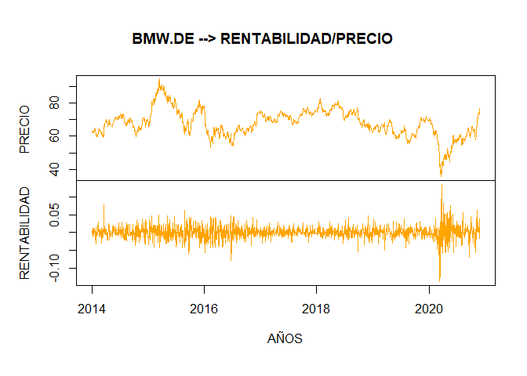

```r
plot.zoo(cbind(xData,dRentCont ),main = paste(sSymbol,"--> RENTABILIDAD/PRECIO"),xlab = "AÑOS",ylab = c("PRECIO ","RENTABILIDAD"), col = "orange")#juntamos el cierre ajustado con la media aritmetica de la rentabilidad
```

# VOLATILIDAD DE GARCH:

- La volatilidad es vista con frecuencia como negativa en tanto que representa incertidumbre y riesgo. Sin embargo, la volatilidad puede ser positiva en el sentido de que puede permitir obtener beneficio si se vende en los picos y se compra en las bajas, tanto más beneficio cuanto más alta sea la volatilidad. La posibilidad de obtener beneficios mediante mercados volátiles es lo que permite a los agentes de mercado a corto plazo obtener sus ganancias, en contraste con la visión inversionista a largo término de comprar y mantener.

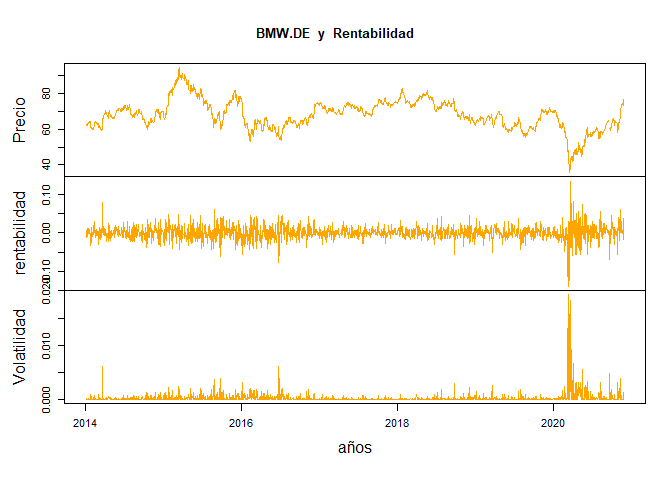

```r
#Volatilidad GARCH
#Plot return squared
plot.zoo(cbind(Ad(mData),dRentCont,dRentCont^2),main = paste(sSymbol," y  Rentabilidad"),xlab = "años",ylab = c("Precio","rentabilidad","Volatilidad"), col = "orange")
```

# TEST DE MEDIAS:

```r
#testing mean
t.test(dRentCont)
```

```
##
##  One Sample t-test
##
## data:  dRentCont
## t = 0.21196, df = 1748, p-value = 0.8322
## alternative hypothesis: true mean is not equal to 0
## 95 percent confidence interval:
##  -0.0007406791  0.0009201661
## sample estimates:
##   mean of x
## 8.97435e-05
```

# ACF & PACF:

```r
# VolProxy=abs(dRentCont) # absolute value
VolProxy = dRentCont^2 #squared
```

# ACF y PACF:

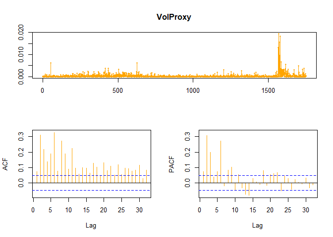

```r
tsdisplay(VolProxy, col = "orange")
```

* Donde observamos que los residuos no son ruido blanco.

# Ljung-Box Test:

- La prueba de Ljung-Box se puede definir de la siguiente manera.
- H0: Los datos se distribuyen de forma independiente (es decir, las correlaciones en la población de la que se toma la muestra son 0, de modo que cualquier correlación observada en los datos es el resultado de la aleatoriedad del proceso de muestreo).
- H1: Los datos no se distribuyen de forma independiente.
- La prueba de Ljung-Box se utiliza comúnmente en autorregresivo integrado de media móvil de modelado (ARIMA). Tenga en cuenta que se aplica a los residuos de un modelo ARIMA equipada, no en la serie original, y en tales aplicaciones, la hipótesis de hecho objeto del ensayo es que los residuos del modelo ARIMA no tienen autocorrelación. Al probar los residuales de un modelo ARIMA estimado, los grados de libertad deben ser ajustados para reflejar la estimación de parámetros.

```r
Box.test(VolProxy,lag = 10,  type = "Lj")
```

```
##
##  Box-Ljung test
##
## data:  VolProxy
## X-squared = 760.79, df = 10, p-value < 2.2e-16
```

```r
Box.test(VolProxy,lag = 20,  type = "Lj")
```

```
##
##  Box-Ljung test
##
## data:  VolProxy
## X-squared = 993.66, df = 20, p-value < 2.2e-16
```

```r
Box.test(VolProxy,lag = 40,  type = "Lj")
```

```
##
##  Box-Ljung test
##
## data:  VolProxy
## X-squared = 1230.8, df = 40, p-value < 2.2e-16
```

# LM test:

- Esta función calcula la prueba ARCH de Engle. La hipótesis nula de esta prueba del Multiplicador de Lagrange es que una serie de residuos no exhibe efectos ARCH. La hipótesis alternativa es que los efectos ARCH(lag) están presentes.

```r
archTest(dRentCont,20)
```

```
##
## Call:
## lm(formula = atsq ~ x)
##
## Residuals:
##        Min         1Q     Median         3Q        Max
## -0.0047684 -0.0002218 -0.0001073  0.0000544  0.0181166
##
## Coefficients:
##               Estimate Std. Error t value Pr(>|t|)
## (Intercept)  9.000e-05  2.557e-05   3.519 0.000444 ***
## x1          -3.635e-02  2.416e-02  -1.505 0.132576
## x2           2.366e-01  2.417e-02   9.787  < 2e-16 ***
## x3           9.265e-02  2.479e-02   3.738 0.000192 ***
## x4          -1.179e-02  2.490e-02  -0.474 0.635720
## x5           8.426e-02  2.489e-02   3.386 0.000726 ***
## x6           2.478e-01  2.497e-02   9.921  < 2e-16 ***
## x7          -2.280e-02  2.559e-02  -0.891 0.373151
## x8           1.235e-01  2.552e-02   4.839 1.42e-06 ***
## x9           7.497e-02  2.568e-02   2.919 0.003553 **
## x10         -4.162e-02  2.568e-02  -1.621 0.105223
## x11          7.900e-02  2.568e-02   3.076 0.002130 **
## x12         -4.406e-02  2.569e-02  -1.715 0.086478 .
## x13         -8.408e-02  2.554e-02  -3.291 0.001017 **
## x14         -8.908e-02  2.562e-02  -3.476 0.000521 ***
## x15          1.820e-02  2.511e-02   0.725 0.468544
## x16         -1.169e-02  2.503e-02  -0.467 0.640494
## x17         -7.626e-03  2.503e-02  -0.305 0.760654
## x18          6.754e-02  2.492e-02   2.710 0.006793 **
## x19         -1.440e-02  2.431e-02  -0.592 0.553891
## x20          5.537e-02  2.430e-02   2.278 0.022826 *
## ---
## Signif. codes:  0 '***' 0.001 '**' 0.01 '*' 0.05 '.' 0.1 ' ' 1
##
## Residual standard error: 0.0008736 on 1708 degrees of freedom
## Multiple R-squared:  0.2415, Adjusted R-squared:  0.2326
## F-statistic: 27.19 on 20 and 1708 DF,  p-value: < 2.2e-16
```

# ARCH(1):

```r
m1 = garchFit(~1+garch(1,0),data = dRentCont,trace = F) # Fit an ARCH(1) model
summary(m1)
```

```
##
## Title:
##  GARCH Modelling
##
## Call:
##  garchFit(formula = ~1 + garch(1, 0), data = dRentCont, trace = F)
##
## Mean and Variance Equation:
##  data ~ 1 + garch(1, 0)
## <environment: 0x000000001db17ad8>
##  [data = dRentCont]
##
## Conditional Distribution:
##  norm
##
## Coefficient(s):
##         mu       omega      alpha1
## 0.00017675  0.00023059  0.31682254
##
## Std. Errors:
##  based on Hessian
##
## Error Analysis:
##         Estimate  Std. Error  t value Pr(>|t|)
## mu     0.0001767   0.0003909    0.452    0.651
## omega  0.0002306   0.0000104   22.178  < 2e-16 ***
## alpha1 0.3168225   0.0454585    6.969 3.18e-12 ***
## ---
## Signif. codes:  0 '***' 0.001 '**' 0.01 '*' 0.05 '.' 0.1 ' ' 1
##
## Log Likelihood:
##  4627.509    normalized:  2.645803
##
## Description:
##  Mon Nov 30 23:16:35 2020 by user: mario
##
##
## Standardised Residuals Tests:
##                                 Statistic p-Value
##  Jarque-Bera Test   R    Chi^2  3745.216  0
##  Shapiro-Wilk Test  R    W      0.9376284 0
##  Ljung-Box Test     R    Q(10)  22.49945  0.01275285
##  Ljung-Box Test     R    Q(15)  30.67453  0.009708666
##  Ljung-Box Test     R    Q(20)  36.29074  0.01421393
##  Ljung-Box Test     R^2  Q(10)  319.1775  0
##  Ljung-Box Test     R^2  Q(15)  383.6313  0
##  Ljung-Box Test     R^2  Q(20)  475.3133  0
##  LM Arch Test       R    TR^2   232.4751  0
##
## Information Criterion Statistics:
##       AIC       BIC       SIC      HQIC
## -5.288175 -5.278798 -5.288181 -5.284709
```

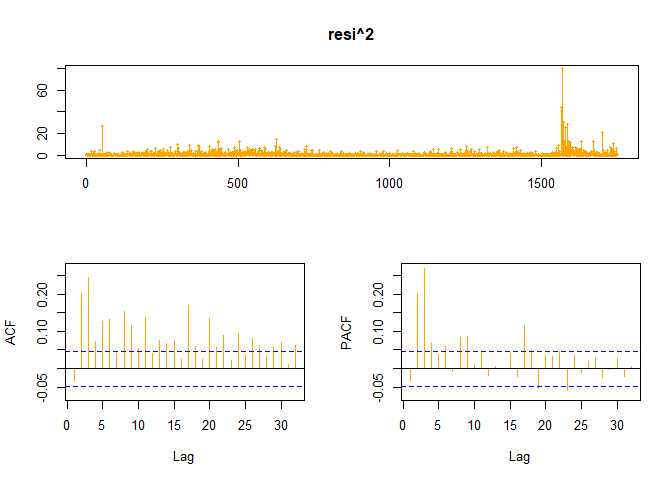

```r
resi = residuals(m1,standardize = T) #residuals
resi = xts(resi,order.by = index(dRentCont)) #residuals as xts
tsdisplay(resi^2, col = "orange") #acf pacf residuals
```

# GARCH(1,1):

```r
m2 = garchFit(~1+garch(1,1),data = dRentCont,trace = F) # Fit an GARCH(1,1) model
summary(m2)
```

```
##
## Title:
##  GARCH Modelling
##
## Call:
##  garchFit(formula = ~1 + garch(1, 1), data = dRentCont, trace = F)
##
## Mean and Variance Equation:
##  data ~ 1 + garch(1, 1)
## <environment: 0x000000001f924448>
##  [data = dRentCont]
##
## Conditional Distribution:
##  norm
##
## Coefficient(s):
##         mu       omega      alpha1       beta1
## 3.0532e-04  2.5007e-06  4.9894e-02  9.4273e-01
##
## Std. Errors:
##  based on Hessian
##
## Error Analysis:
##         Estimate  Std. Error  t value Pr(>|t|)
## mu     3.053e-04   3.360e-04    0.909   0.3635
## omega  2.501e-06   9.781e-07    2.557   0.0106 *
## alpha1 4.989e-02   8.002e-03    6.235  4.5e-10 ***
## beta1  9.427e-01   9.548e-03   98.734  < 2e-16 ***
## ---
## Signif. codes:  0 '***' 0.001 '**' 0.01 '*' 0.05 '.' 0.1 ' ' 1
##
## Log Likelihood:
##  4799.462    normalized:  2.744118
##
## Description:
##  Mon Nov 30 23:16:36 2020 by user: mario
##
##
## Standardised Residuals Tests:
##                                 Statistic p-Value
##  Jarque-Bera Test   R    Chi^2  749.4246  0
##  Shapiro-Wilk Test  R    W      0.9722568 0
##  Ljung-Box Test     R    Q(10)  21.9004   0.01562014
##  Ljung-Box Test     R    Q(15)  26.40683  0.03395787
##  Ljung-Box Test     R    Q(20)  32.28662  0.04033832
##  Ljung-Box Test     R^2  Q(10)  21.35063  0.01877703
##  Ljung-Box Test     R^2  Q(15)  22.86262  0.08710055
##  Ljung-Box Test     R^2  Q(20)  26.26798  0.1571427
##  LM Arch Test       R    TR^2   21.86675  0.03904063
##
## Information Criterion Statistics:
##       AIC       BIC       SIC      HQIC
## -5.483661 -5.471159 -5.483672 -5.479039
```

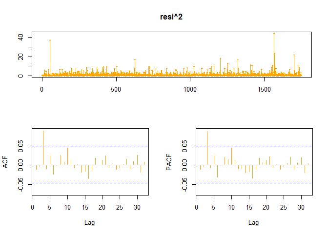

```r
resi = residuals(m2,standardize = T) #residuals
resi = xts(resi,order.by = index(dRentCont)) #residuals as xts
tsdisplay(resi^2, col = "orange") #acf pacf residuals
```

```r
plot(m2, which = 0)
```

# t-student:

```r
m3 = garchFit(~1+garch(1,1),data = dRentCont,trace = F,cond.dist = "std")
summary(m3)
```

```
##
## Title:
##  GARCH Modelling
##
## Call:
##  garchFit(formula = ~1 + garch(1, 1), data = dRentCont, cond.dist = "std",
##     trace = F)
##
## Mean and Variance Equation:
##  data ~ 1 + garch(1, 1)
## <environment: 0x000000001e9e5678>
##  [data = dRentCont]
##
## Conditional Distribution:
##  std
##
## Coefficient(s):
##         mu       omega      alpha1       beta1       shape
## 3.8524e-06  2.0319e-06  4.6988e-02  9.4825e-01  4.9742e+00
##
## Std. Errors:
##  based on Hessian
##
## Error Analysis:
##         Estimate  Std. Error  t value Pr(>|t|)
## mu     3.852e-06   3.085e-04    0.012   0.9900
## omega  2.032e-06   9.632e-07    2.110   0.0349 *
## alpha1 4.699e-02   9.910e-03    4.741 2.12e-06 ***
## beta1  9.482e-01   1.047e-02   90.541  < 2e-16 ***
## shape  4.974e+00   6.058e-01    8.211 2.22e-16 ***
## ---
## Signif. codes:  0 '***' 0.001 '**' 0.01 '*' 0.05 '.' 0.1 ' ' 1
##
## Log Likelihood:
##  4871.282    normalized:  2.785181
##
## Description:
##  Mon Nov 30 23:16:37 2020 by user: mario
##
##
## Standardised Residuals Tests:
##                                 Statistic p-Value
##  Jarque-Bera Test   R    Chi^2  779.926   0
##  Shapiro-Wilk Test  R    W      0.9718859 0
##  Ljung-Box Test     R    Q(10)  22.09689  0.01461855
##  Ljung-Box Test     R    Q(15)  26.50925  0.03299867
##  Ljung-Box Test     R    Q(20)  32.38958  0.03931994
##  Ljung-Box Test     R^2  Q(10)  24.82233  0.005692648
##  Ljung-Box Test     R^2  Q(15)  26.31576  0.03483185
##  Ljung-Box Test     R^2  Q(20)  29.88551  0.07173019
##  LM Arch Test       R    TR^2   25.36204  0.01319746
##
## Information Criterion Statistics:
##       AIC       BIC       SIC      HQIC
## -5.564645 -5.549017 -5.564661 -5.558868
```

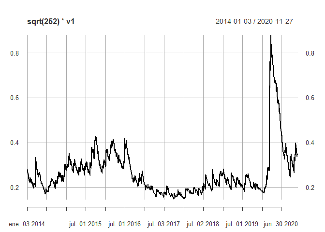

```r
plot(m3, which = 0)


v1 = volatility(m3)  # Obtain volatility
v1 = xts(v1,order.by = index(dRentCont)) #  volatility as XTS
plot(sqrt(252)*v1)
```

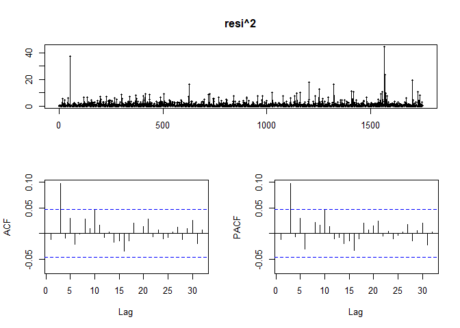

```r
resi = residuals(m3,standardize = T) # Standardized residuals
resi = xts(resi,order.by = index(dRentCont)) # Standardized residuals as XTS
tsdisplay(resi^2) #acf pacf residuals
```

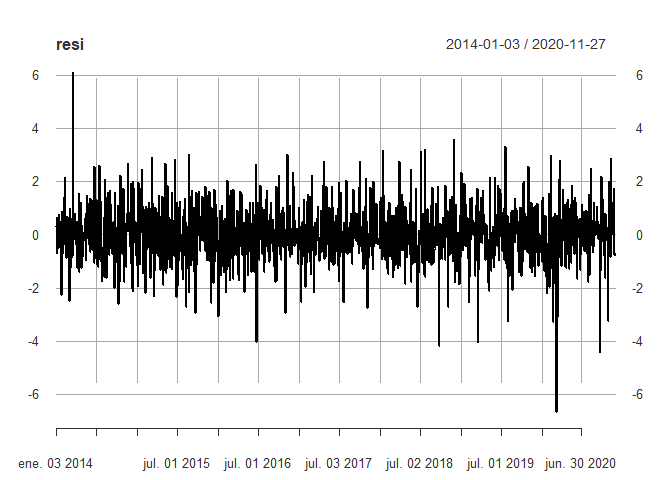

```r
plot(resi, which = 0)
```

```r
predict(m3) #forecast volatility
```

```
##    meanForecast  meanError standardDeviation
## 1   3.85243e-06 0.02145798        0.02145798
## 2   3.85243e-06 0.02145422        0.02145422
## 3   3.85243e-06 0.02145048        0.02145048
## 4   3.85243e-06 0.02144675        0.02144675
## 5   3.85243e-06 0.02144304        0.02144304
## 6   3.85243e-06 0.02143935        0.02143935
## 7   3.85243e-06 0.02143567        0.02143567
## 8   3.85243e-06 0.02143202        0.02143202
## 9   3.85243e-06 0.02142837        0.02142837
## 10  3.85243e-06 0.02142475        0.02142475
```

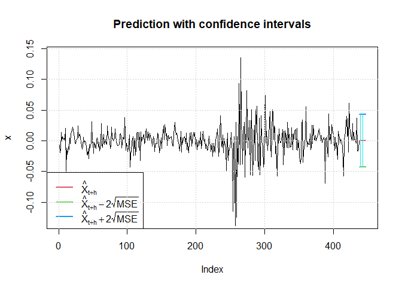

```
##    meanForecast  meanError standardDeviation lowerInterval upperInterval
## 1   3.85243e-06 0.02145798        0.02145798   -0.04291212    0.04291982
## 2   3.85243e-06 0.02145422        0.02145422   -0.04290459    0.04291230
## 3   3.85243e-06 0.02145048        0.02145048   -0.04289711    0.04290481
## 4   3.85243e-06 0.02144675        0.02144675   -0.04288965    0.04289736
## 5   3.85243e-06 0.02144304        0.02144304   -0.04288223    0.04288994
## 6   3.85243e-06 0.02143935        0.02143935   -0.04287485    0.04288255
## 7   3.85243e-06 0.02143567        0.02143567   -0.04286750    0.04287520
## 8   3.85243e-06 0.02143202        0.02143202   -0.04286018    0.04286788
## 9   3.85243e-06 0.02142837        0.02142837   -0.04285289    0.04286060
## 10  3.85243e-06 0.02142475        0.02142475   -0.04284564    0.04285335
```

```r
predict(m3, n.ahead = 10, plot = TRUE, crit_val = 2) #plot with 2*standard error
```

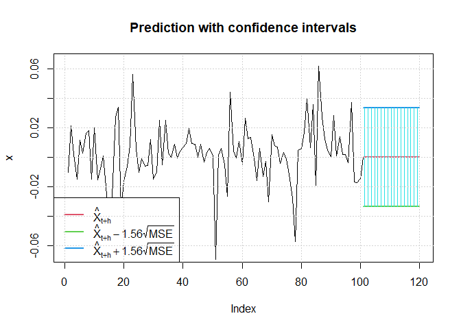

```
##    meanForecast  meanError standardDeviation lowerInterval upperInterval
## 1   3.85243e-06 0.02145798        0.02145798   -0.03346920    0.03347690
## 2   3.85243e-06 0.02145422        0.02145422   -0.03346333    0.03347103
## 3   3.85243e-06 0.02145048        0.02145048   -0.03345749    0.03346519
## 4   3.85243e-06 0.02144675        0.02144675   -0.03345167    0.03345938
## 5   3.85243e-06 0.02144304        0.02144304   -0.03344589    0.03345359
## 6   3.85243e-06 0.02143935        0.02143935   -0.03344013    0.03344783
## 7   3.85243e-06 0.02143567        0.02143567   -0.03343439    0.03344210
## 8   3.85243e-06 0.02143202        0.02143202   -0.03342869    0.03343639
## 9   3.85243e-06 0.02142837        0.02142837   -0.03342300    0.03343071
## 10  3.85243e-06 0.02142475        0.02142475   -0.03341735    0.03342505
## 11  3.85243e-06 0.02142114        0.02142114   -0.03341172    0.03341943
## 12  3.85243e-06 0.02141755        0.02141755   -0.03340612    0.03341382
## 13  3.85243e-06 0.02141397        0.02141397   -0.03340054    0.03340824
## 14  3.85243e-06 0.02141041        0.02141041   -0.03339499    0.03340269
## 15  3.85243e-06 0.02140687        0.02140687   -0.03338946    0.03339717
## 16  3.85243e-06 0.02140334        0.02140334   -0.03338396    0.03339167
## 17  3.85243e-06 0.02139983        0.02139983   -0.03337848    0.03338619
## 18  3.85243e-06 0.02139634        0.02139634   -0.03337303    0.03338074
## 19  3.85243e-06 0.02139286        0.02139286   -0.03336761    0.03337531
## 20  3.85243e-06 0.02138940        0.02138940   -0.03336221    0.03336991
```

```r
predict(m3,n.ahead = 20,plot = TRUE,conf = .9,nx = 100) # plot 100 data with 90% confidence
```

## Modelo VAR

- Generar un modelo VAR de las series de rendimientos diarios de BMW y VOLKSWAGEN.
- Generamos un dataframe con los rendiemientos diarios de los dos activos en cuestion.

```r
getSymbols('BMW.DE', from = '2014-01-01', to = Sys.Date())
```

```
## [1] "BMW.DE"
```

```r
getSymbols('VOW.DE', from = '2014-01-01', to = Sys.Date())
```

```
## [1] "VOW.DE"
```

```r
s_bmw <- BMW.DE[,6]
s_vol <- VOW.DE[,6]
ren_vol <- dailyReturn(s_vol)
ren_bmw <- dailyReturn(s_bmw)
df_ren <- cbind(ren_bmw, ren_vol)
df_ren <- na.omit(df_ren)
colnames(df_ren)=c("BMW","VOLks")
```

- Después realizamos un gráfico para seguir la evolucion del valor de los dos activos y sus rendimientos

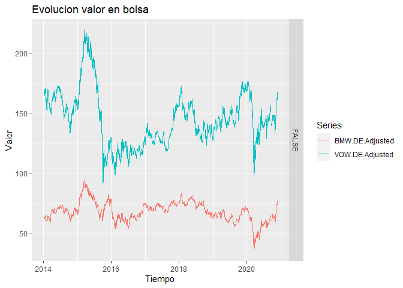

```r
df <- cbind(s_bmw, s_vol)

autoplot(df, facets = FALSE) +
  ggtitle("Evolucion valor en bolsa") +
  xlab("Tiempo") +
  ylab("Valor")
```

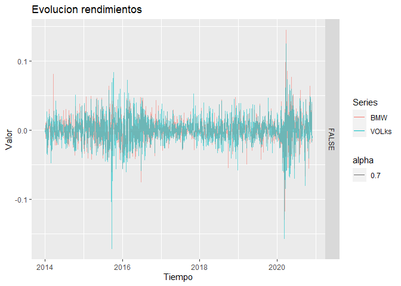

```r
autoplot(df_ren, alpha = 0.7, facets = FALSE) +
  ggtitle("Evolucion rendimientos") +
  xlab("Tiempo") +
  ylab("Valor")
```

- El modelo VAR estimado presenta parametros estadisticamente significativos al 90% de confinza, los siguientes pasos será ver si las predicciones que realizan son adecuadas.
- Con el test de causalidad también se observa que no hay una relación dinámica, es decir, no hay relacion bidireccional que nos permita explicar una serie en función de otra.

```r
m_var <- VAR(df_ren)
summary(m_var) # hay una significativa
```

```
##
## VAR Estimation Results:
## =========================
## Endogenous variables: BMW, VOLks
## Deterministic variables: const
## Sample size: 1749
## Log Likelihood: 9685.969
## Roots of the characteristic polynomial:
## 0.05496 0.04845
## Call:
## VAR(y = df_ren)
##
##
## Estimation results for equation BMW:
## ====================================
## BMW = BMW.l1 + VOLks.l1 + const
##
##            Estimate Std. Error t value Pr(>|t|)
## BMW.l1   -0.0662868  0.0365593  -1.813 0.069984 .
## VOLks.l1  0.1090506  0.0322391   3.383 0.000734 ***
## const     0.0002429  0.0004217   0.576 0.564772
## ---
## Signif. codes:  0 '***' 0.001 '**' 0.01 '*' 0.05 '.' 0.1 ' ' 1
##
##
## Residual standard error: 0.01764 on 1746 degrees of freedom
## Multiple R-Squared: 0.007258,    Adjusted R-squared: 0.006121
## F-statistic: 6.383 on 2 and 1746 DF,  p-value: 0.00173
##
##
## Estimation results for equation VOLks:
## ======================================
## VOLks = BMW.l1 + VOLks.l1 + const
##
##            Estimate Std. Error t value Pr(>|t|)
## BMW.l1   -0.0198337  0.0415278  -0.478    0.633
## VOLks.l1  0.0727979  0.0366204   1.988    0.047 *
## const     0.0001724  0.0004791   0.360    0.719
## ---
## Signif. codes:  0 '***' 0.001 '**' 0.01 '*' 0.05 '.' 0.1 ' ' 1
##
##
## Residual standard error: 0.02003 on 1746 degrees of freedom
## Multiple R-Squared: 0.003675,    Adjusted R-squared: 0.002534
## F-statistic:  3.22 on 2 and 1746 DF,  p-value: 0.04019
##
##
##
## Covariance matrix of residuals:
##             BMW     VOLks
## BMW   0.0003110 0.0002675
## VOLks 0.0002675 0.0004013
##
## Correlation matrix of residuals:
##          BMW  VOLks
## BMW   1.0000 0.7572
## VOLks 0.7572 1.0000
```

```r
causality(m_var) # rechazamos, puede haber bidericcionalidad
```

```
## $Granger
##
##  Granger causality H0: BMW do not Granger-cause VOLks
##
## data:  VAR object m_var
## F-Test = 0.2281, df1 = 1, df2 = 3492, p-value = 0.633
##
##
## $Instant
##
##  H0: No instantaneous causality between: BMW and VOLks
##
## data:  VAR object m_var
## Chi-squared = 637.38, df = 1, p-value < 2.2e-16
```

```r
shock_m_var <- irf(m_var)
shock_m_var
```

```
##
## Impulse response coefficients
## $BMW
##                BMW        VOLks
##  [1,] 1.763567e-02 1.516886e-02
##  [2,] 4.851615e-04 7.544802e-04
##  [3,] 5.011671e-05 4.530201e-05
##  [4,] 1.618136e-06 2.303891e-06
##  [5,] 1.439796e-07 1.356247e-07
##  [6,] 5.246014e-09 7.017544e-09
##  [7,] 4.175259e-10 4.068145e-10
##  [8,] 1.668691e-11 2.133415e-11
##  [9,] 1.220380e-12 1.222117e-12
## [10,] 5.237759e-14 6.476291e-14
## [11,] 3.590491e-15 3.675761e-15
```

[output cut: 74 more lines]

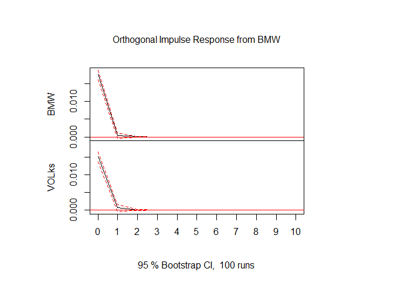

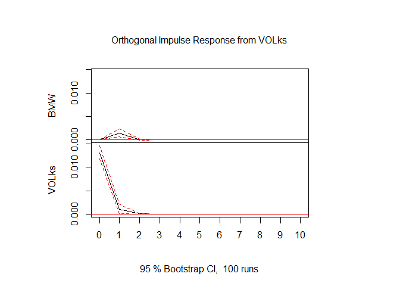

```r
plot(shock_m_var, which = 0)
```

- Por último, calculamos las predicciones de nuestro modelo VAR, aunque como observamos no son muy buenas ya que todas son valores muy proximos a 0.

```r
predict(m_var, n.ahead = 8, ci = 0.95, plot = T)
```

```
## $BMW
##              fcst       lower      upper         CI
## [1,] 0.0002321581 -0.03433312 0.03479743 0.03456528
## [2,] 0.0002081447 -0.03448312 0.03489940 0.03469126
## [3,] 0.0002459621 -0.03444544 0.03493737 0.03469140
## [4,] 0.0002461444 -0.03444526 0.03493755 0.03469140
## [5,] 0.0002462463 -0.03444516 0.03493765 0.03469140
## [6,] 0.0002462474 -0.03444516 0.03493765 0.03469140
## [7,] 0.0002462477 -0.03444516 0.03493765 0.03469140
## [8,] 0.0002462477 -0.03444516 0.03493765 0.03469140
##
## $VOLks
##               fcst       lower      upper         CI
## [1,] -0.0001773109 -0.03944007 0.03908545 0.03926276
## [2,]  0.0001548799 -0.03918005 0.03948981 0.03933493
## [3,]  0.0001795389 -0.03915557 0.03951465 0.03933511
## [4,]  0.0001805840 -0.03915453 0.03951569 0.03933511
## [5,]  0.0001806565 -0.03915445 0.03951577 0.03933511
## [6,]  0.0001806597 -0.03915445 0.03951577 0.03933511
## [7,]  0.0001806599 -0.03915445 0.03951577 0.03933511
## [8,]  0.0001806599 -0.03915445 0.03951577 0.03933511
```